# Project: The Movie Database (TMDb) Data Analysis

- Introduction
- Data Wrangling
- 1. Gathering data
- 2. Assessing data
- 3. Cleaning data
- Exploratory Data Analysis
- Conclusions
- Limitation

## Introduction

> In this project we will analyze data of 10,000 movies collected from The Movie Database (TMDb), including user ratings, revenue, budget and many more data related to each movie

> In Particular we will address the following questions:
> - what is the 5 most popular movies?
> - What is the 5 most costable movies ?
> - What is the 5 most revenue movies ?
> - What is the heighest 5 vote count movies ?
> - What is the heighest 5 vote average movies ?
> - Is there a relation between budget and revenue?
> - Is there a relation between popularity and budget?
> - Is there a relation between popularity and revenue?
> - what is the top 10 years related to movie released count?
> - What is the top 10 years related to popularity?
> - What is the top 10 years related to budget?
> - What is the top 10 years related to revenue?
> - What is the most frequent genres?
> - What is the most popular genres?
> - What is the most costable genres?
> - What is the most profitable genres?
> - Who is the Cast Member that participated in highest no of movies?
> - What is The top 5 Production companies with highest money spent in budget?

### Packages imported

```python
# Import Packages needed for analysis the data
import numpy as np
import pandas as pd
import matplotlib.pyplot as plt
import seaborn as sns


%matplotlib inline
```

## Data Wrangling

> In this section of the report, we will load in the data, check for cleanliness, and then trim and clean dataset for analysis.

### 1. Gather Data:

> Download file (tmdb-movies.csv) and load it in pandas dataframe

```python
# Load data and print it out. Perform operations to inspect data
#   types and look for instances of missing or possibly errant data.
df = pd.read_csv('tmdb-movies.csv')
df.head()
```

|  | id | imdb_id | popularity | budget | revenue | original_title | cast | homepage | director | tagline | ... | overview | runtime | genres | production_companies | release_date | vote_count | vote_average | release_year | budget_adj | revenue_adj |
| --- | --- | --- | --- | --- | --- | --- | --- | --- | --- | --- | --- | --- | --- | --- | --- | --- | --- | --- | --- | --- | --- |
| 0 | 135397 | tt0369610 | 32.985763 | 150000000 | 1513528810 | Jurassic World | Chris Pratt\|Bryce Dallas Howard\|Irrfan Khan\|Vi... | http://www.jurassicworld.com/ | Colin Trevorrow | The park is open. | ... | Twenty-two years after the events of Jurassic ... | 124 | Action\|Adventure\|Science Fiction\|Thriller | Universal Studios\|Amblin Entertainment\|Legenda... | 6/9/15 | 5562 | 6.5 | 2015 | 1.379999e+08 | 1.392446e+09 |
| 1 | 76341 | tt1392190 | 28.419936 | 150000000 | 378436354 | Mad Max: Fury Road | Tom Hardy\|Charlize Theron\|Hugh Keays-Byrne\|Nic... | http://www.madmaxmovie.com/ | George Miller | What a Lovely Day. | ... | An apocalyptic story set in the furthest reach... | 120 | Action\|Adventure\|Science Fiction\|Thriller | Village Roadshow Pictures\|Kennedy Miller Produ... | 5/13/15 | 6185 | 7.1 | 2015 | 1.379999e+08 | 3.481613e+08 |
| 2 | 262500 | tt2908446 | 13.112507 | 110000000 | 295238201 | Insurgent | Shailene Woodley\|Theo James\|Kate Winslet\|Ansel... | http://www.thedivergentseries.movie/#insurgent | Robert Schwentke | One Choice Can Destroy You | ... | Beatrice Prior must confront her inner demons ... | 119 | Adventure\|Science Fiction\|Thriller | Summit Entertainment\|Mandeville Films\|Red Wago... | 3/18/15 | 2480 | 6.3 | 2015 | 1.012000e+08 | 2.716190e+08 |
| 3 | 140607 | tt2488496 | 11.173104 | 200000000 | 2068178225 | Star Wars: The Force Awakens | Harrison Ford\|Mark Hamill\|Carrie Fisher\|Adam D... | http://www.starwars.com/films/star-wars-episod... | J.J. Abrams | Every generation has a story. | ... | Thirty years after defeating the Galactic Empi... | 136 | Action\|Adventure\|Science Fiction\|Fantasy | Lucasfilm\|Truenorth Productions\|Bad Robot | 12/15/15 | 5292 | 7.5 | 2015 | 1.839999e+08 | 1.902723e+09 |
| 4 | 168259 | tt2820852 | 9.335014 | 190000000 | 1506249360 | Furious 7 | Vin Diesel\|Paul Walker\|Jason Statham\|Michelle ... | http://www.furious7.com/ | James Wan | Vengeance Hits Home | ... | Deckard Shaw seeks revenge against Dominic Tor... | 137 | Action\|Crime\|Thriller | Universal Pictures\|Original Film\|Media Rights ... | 4/1/15 | 2947 | 7.3 | 2015 | 1.747999e+08 | 1.385749e+09 |

5 rows × 21 columns

### 2. Assess Data:

### Assess Data visually and programatically

> a. Assess Data visually by open file using excel program and show them here in the notebook

```python
df
```

|  | id | imdb_id | popularity | budget | revenue | original_title | cast | homepage | director | tagline | ... | overview | runtime | genres | production_companies | release_date | vote_count | vote_average | release_year | budget_adj | revenue_adj |
| --- | --- | --- | --- | --- | --- | --- | --- | --- | --- | --- | --- | --- | --- | --- | --- | --- | --- | --- | --- | --- | --- |
| 0 | 135397 | tt0369610 | 32.985763 | 150000000 | 1513528810 | Jurassic World | Chris Pratt\|Bryce Dallas Howard\|Irrfan Khan\|Vi... | http://www.jurassicworld.com/ | Colin Trevorrow | The park is open. | ... | Twenty-two years after the events of Jurassic ... | 124 | Action\|Adventure\|Science Fiction\|Thriller | Universal Studios\|Amblin Entertainment\|Legenda... | 6/9/15 | 5562 | 6.5 | 2015 | 1.379999e+08 | 1.392446e+09 |
| 1 | 76341 | tt1392190 | 28.419936 | 150000000 | 378436354 | Mad Max: Fury Road | Tom Hardy\|Charlize Theron\|Hugh Keays-Byrne\|Nic... | http://www.madmaxmovie.com/ | George Miller | What a Lovely Day. | ... | An apocalyptic story set in the furthest reach... | 120 | Action\|Adventure\|Science Fiction\|Thriller | Village Roadshow Pictures\|Kennedy Miller Produ... | 5/13/15 | 6185 | 7.1 | 2015 | 1.379999e+08 | 3.481613e+08 |
| 2 | 262500 | tt2908446 | 13.112507 | 110000000 | 295238201 | Insurgent | Shailene Woodley\|Theo James\|Kate Winslet\|Ansel... | http://www.thedivergentseries.movie/#insurgent | Robert Schwentke | One Choice Can Destroy You | ... | Beatrice Prior must confront her inner demons ... | 119 | Adventure\|Science Fiction\|Thriller | Summit Entertainment\|Mandeville Films\|Red Wago... | 3/18/15 | 2480 | 6.3 | 2015 | 1.012000e+08 | 2.716190e+08 |
| 3 | 140607 | tt2488496 | 11.173104 | 200000000 | 2068178225 | Star Wars: The Force Awakens | Harrison Ford\|Mark Hamill\|Carrie Fisher\|Adam D... | http://www.starwars.com/films/star-wars-episod... | J.J. Abrams | Every generation has a story. | ... | Thirty years after defeating the Galactic Empi... | 136 | Action\|Adventure\|Science Fiction\|Fantasy | Lucasfilm\|Truenorth Productions\|Bad Robot | 12/15/15 | 5292 | 7.5 | 2015 | 1.839999e+08 | 1.902723e+09 |
| 4 | 168259 | tt2820852 | 9.335014 | 190000000 | 1506249360 | Furious 7 | Vin Diesel\|Paul Walker\|Jason Statham\|Michelle ... | http://www.furious7.com/ | James Wan | Vengeance Hits Home | ... | Deckard Shaw seeks revenge against Dominic Tor... | 137 | Action\|Crime\|Thriller | Universal Pictures\|Original Film\|Media Rights ... | 4/1/15 | 2947 | 7.3 | 2015 | 1.747999e+08 | 1.385749e+09 |
| ... | ... | ... | ... | ... | ... | ... | ... | ... | ... | ... | ... | ... | ... | ... | ... | ... | ... | ... | ... | ... | ... |
| 10861 | 21 | tt0060371 | 0.080598 | 0 | 0 | The Endless Summer | Michael Hynson\|Robert August\|Lord 'Tally Ho' B... | NaN | Bruce Brown | NaN | ... | The Endless Summer, by Bruce Brown, is one of ... | 95 | Documentary | Bruce Brown Films | 6/15/66 | 11 | 7.4 | 1966 | 0.000000e+00 | 0.000000e+00 |
| 10862 | 20379 | tt0060472 | 0.065543 | 0 | 0 | Grand Prix | James Garner\|Eva Marie Saint\|Yves Montand\|Tosh... | NaN | John Frankenheimer | Cinerama sweeps YOU into a drama of speed and ... | ... | Grand Prix driver Pete Aron is fired by his te... | 176 | Action\|Adventure\|Drama | Cherokee Productions\|Joel Productions\|Douglas ... | 12/21/66 | 20 | 5.7 | 1966 | 0.000000e+00 | 0.000000e+00 |
| 10863 | 39768 | tt0060161 | 0.065141 | 0 | 0 | Beregis Avtomobilya | Innokentiy Smoktunovskiy\|Oleg Efremov\|Georgi Z... | NaN | Eldar Ryazanov | NaN | ... | An insurance agent who moonlights as a carthie... | 94 | Mystery\|Comedy | Mosfilm | 1/1/66 | 11 | 6.5 | 1966 | 0.000000e+00 | 0.000000e+00 |
| 10864 | 21449 | tt0061177 | 0.064317 | 0 | 0 | What's Up, Tiger Lily? | Tatsuya Mihashi\|Akiko Wakabayashi\|Mie Hama\|Joh... | NaN | Woody Allen | WOODY ALLEN STRIKES BACK! | ... | In comic Woody Allen's film debut, he took the... | 80 | Action\|Comedy | Benedict Pictures Corp. | 11/2/66 | 22 | 5.4 | 1966 | 0.000000e+00 | 0.000000e+00 |
| 10865 | 22293 | tt0060666 | 0.035919 | 19000 | 0 | Manos: The Hands of Fate | Harold P. Warren\|Tom Neyman\|John Reynolds\|Dian... | NaN | Harold P. Warren | It's Shocking! It's Beyond Your Imagination! | ... | A family gets lost on the road and stumbles up... | 74 | Horror | Norm-Iris | 11/15/66 | 15 | 1.5 | 1966 | 1.276423e+05 | 0.000000e+00 |

10866 rows × 21 columns

```python
df.head()
```

|  | id | imdb_id | popularity | budget | revenue | original_title | cast | homepage | director | tagline | ... | overview | runtime | genres | production_companies | release_date | vote_count | vote_average | release_year | budget_adj | revenue_adj |
| --- | --- | --- | --- | --- | --- | --- | --- | --- | --- | --- | --- | --- | --- | --- | --- | --- | --- | --- | --- | --- | --- |
| 0 | 135397 | tt0369610 | 32.985763 | 150000000 | 1513528810 | Jurassic World | Chris Pratt\|Bryce Dallas Howard\|Irrfan Khan\|Vi... | http://www.jurassicworld.com/ | Colin Trevorrow | The park is open. | ... | Twenty-two years after the events of Jurassic ... | 124 | Action\|Adventure\|Science Fiction\|Thriller | Universal Studios\|Amblin Entertainment\|Legenda... | 6/9/15 | 5562 | 6.5 | 2015 | 1.379999e+08 | 1.392446e+09 |
| 1 | 76341 | tt1392190 | 28.419936 | 150000000 | 378436354 | Mad Max: Fury Road | Tom Hardy\|Charlize Theron\|Hugh Keays-Byrne\|Nic... | http://www.madmaxmovie.com/ | George Miller | What a Lovely Day. | ... | An apocalyptic story set in the furthest reach... | 120 | Action\|Adventure\|Science Fiction\|Thriller | Village Roadshow Pictures\|Kennedy Miller Produ... | 5/13/15 | 6185 | 7.1 | 2015 | 1.379999e+08 | 3.481613e+08 |
| 2 | 262500 | tt2908446 | 13.112507 | 110000000 | 295238201 | Insurgent | Shailene Woodley\|Theo James\|Kate Winslet\|Ansel... | http://www.thedivergentseries.movie/#insurgent | Robert Schwentke | One Choice Can Destroy You | ... | Beatrice Prior must confront her inner demons ... | 119 | Adventure\|Science Fiction\|Thriller | Summit Entertainment\|Mandeville Films\|Red Wago... | 3/18/15 | 2480 | 6.3 | 2015 | 1.012000e+08 | 2.716190e+08 |
| 3 | 140607 | tt2488496 | 11.173104 | 200000000 | 2068178225 | Star Wars: The Force Awakens | Harrison Ford\|Mark Hamill\|Carrie Fisher\|Adam D... | http://www.starwars.com/films/star-wars-episod... | J.J. Abrams | Every generation has a story. | ... | Thirty years after defeating the Galactic Empi... | 136 | Action\|Adventure\|Science Fiction\|Fantasy | Lucasfilm\|Truenorth Productions\|Bad Robot | 12/15/15 | 5292 | 7.5 | 2015 | 1.839999e+08 | 1.902723e+09 |
| 4 | 168259 | tt2820852 | 9.335014 | 190000000 | 1506249360 | Furious 7 | Vin Diesel\|Paul Walker\|Jason Statham\|Michelle ... | http://www.furious7.com/ | James Wan | Vengeance Hits Home | ... | Deckard Shaw seeks revenge against Dominic Tor... | 137 | Action\|Crime\|Thriller | Universal Pictures\|Original Film\|Media Rights ... | 4/1/15 | 2947 | 7.3 | 2015 | 1.747999e+08 | 1.385749e+09 |

5 rows × 21 columns

```python
df.tail()
```

|  | id | imdb_id | popularity | budget | revenue | original_title | cast | homepage | director | tagline | ... | overview | runtime | genres | production_companies | release_date | vote_count | vote_average | release_year | budget_adj | revenue_adj |
| --- | --- | --- | --- | --- | --- | --- | --- | --- | --- | --- | --- | --- | --- | --- | --- | --- | --- | --- | --- | --- | --- |
| 10861 | 21 | tt0060371 | 0.080598 | 0 | 0 | The Endless Summer | Michael Hynson\|Robert August\|Lord 'Tally Ho' B... | NaN | Bruce Brown | NaN | ... | The Endless Summer, by Bruce Brown, is one of ... | 95 | Documentary | Bruce Brown Films | 6/15/66 | 11 | 7.4 | 1966 | 0.000000 | 0.0 |
| 10862 | 20379 | tt0060472 | 0.065543 | 0 | 0 | Grand Prix | James Garner\|Eva Marie Saint\|Yves Montand\|Tosh... | NaN | John Frankenheimer | Cinerama sweeps YOU into a drama of speed and ... | ... | Grand Prix driver Pete Aron is fired by his te... | 176 | Action\|Adventure\|Drama | Cherokee Productions\|Joel Productions\|Douglas ... | 12/21/66 | 20 | 5.7 | 1966 | 0.000000 | 0.0 |
| 10863 | 39768 | tt0060161 | 0.065141 | 0 | 0 | Beregis Avtomobilya | Innokentiy Smoktunovskiy\|Oleg Efremov\|Georgi Z... | NaN | Eldar Ryazanov | NaN | ... | An insurance agent who moonlights as a carthie... | 94 | Mystery\|Comedy | Mosfilm | 1/1/66 | 11 | 6.5 | 1966 | 0.000000 | 0.0 |
| 10864 | 21449 | tt0061177 | 0.064317 | 0 | 0 | What's Up, Tiger Lily? | Tatsuya Mihashi\|Akiko Wakabayashi\|Mie Hama\|Joh... | NaN | Woody Allen | WOODY ALLEN STRIKES BACK! | ... | In comic Woody Allen's film debut, he took the... | 80 | Action\|Comedy | Benedict Pictures Corp. | 11/2/66 | 22 | 5.4 | 1966 | 0.000000 | 0.0 |
| 10865 | 22293 | tt0060666 | 0.035919 | 19000 | 0 | Manos: The Hands of Fate | Harold P. Warren\|Tom Neyman\|John Reynolds\|Dian... | NaN | Harold P. Warren | It's Shocking! It's Beyond Your Imagination! | ... | A family gets lost on the road and stumbles up... | 74 | Horror | Norm-Iris | 11/15/66 | 15 | 1.5 | 1966 | 127642.279154 | 0.0 |

5 rows × 21 columns

```python
df.sample(5)
```

|  | id | imdb_id | popularity | budget | revenue | original_title | cast | homepage | director | tagline | ... | overview | runtime | genres | production_companies | release_date | vote_count | vote_average | release_year | budget_adj | revenue_adj |
| --- | --- | --- | --- | --- | --- | --- | --- | --- | --- | --- | --- | --- | --- | --- | --- | --- | --- | --- | --- | --- | --- |
| 9452 | 13704 | tt0095519 | 1.651962 | 8000000 | 22433275 | License to Drive | Corey Haim\|Corey Feldman\|Carol Kane\|Heather Gr... | NaN | Greg Beeman | Some guys get all the brakes! | ... | Teenager Les Anderson thinks his life can't ge... | 90 | Comedy\|Family | 20th Century Fox\|Davis Entertainment | 7/6/88 | 52 | 6.2 | 1988 | 1.475113e+07 | 4.136451e+07 |
| 9549 | 14285 | tt0096257 | 0.211124 | 0 | 0 | The Thin Blue Line | Randall Adams\|David Harris\|Gus Rose\|Jackie Joh... | NaN | Errol Morris | A softcore movie, Dr. Death, a chocolate milks... | ... | Errol Morris's unique documentary dramatically... | 103 | Mystery\|Documentary\|Crime | Third Floor Productions | 8/28/88 | 54 | 8.0 | 1988 | 0.000000e+00 | 0.000000e+00 |
| 2293 | 46713 | tt1563719 | 0.200241 | 2300000 | 0 | Hunt to Kill | Steve Austin\|Eric Roberts\|Gil Bellows\|Gary Dan... | NaN | Keoni Waxman | Survival of the baddest | ... | A U.S. Border Patrol agent Jim Rhodes, a tough... | 98 | Action\|Adventure\|Thriller | NGN Productions\|Nasser Group, North | 11/6/10 | 18 | 5.1 | 2010 | 2.300000e+06 | 0.000000e+00 |
| 3199 | 15544 | tt0806147 | 0.259840 | 0 | 0 | Extreme Movie | Patrick J. Adams\|Ryan Pinkston\|Denise Boutte\|M... | NaN | Adam Jay Epstein\|Andrew Jacobson | UNRATED. A film with many happy endings... | ... | A sketch comedy movie about the joys and embar... | 88 | Comedy | FlipZide Pictures | 12/5/08 | 19 | 3.4 | 2008 | 0.000000e+00 | 0.000000e+00 |
| 8191 | 37653 | tt0114732 | 0.324339 | 7500000 | 0 | Les Trois Frères | Pascal Légitimus\|Didier Bourdon\|Bernard Campa... | NaN | Bernard Campan\|Didier Bourdon | NaN | ... | Three half-brothers are reunited at their moth... | 105 | Comedy | Renn Productions\|Prima Films\|Canal+ | 12/13/95 | 54 | 7.0 | 1995 | 1.073225e+07 | 0.000000e+00 |

5 rows × 21 columns

> b.Assess Data Programatically

```python
df.shape
```

```
(10866, 21)
```

```python
df.info()
```

```
<class 'pandas.core.frame.DataFrame'>
RangeIndex: 10866 entries, 0 to 10865
Data columns (total 21 columns):
 #   Column                Non-Null Count  Dtype
---  ------                --------------  -----
 0   id                    10866 non-null  int64
 1   imdb_id               10856 non-null  object
 2   popularity            10866 non-null  float64
 3   budget                10866 non-null  int64
 4   revenue               10866 non-null  int64
 5   original_title        10866 non-null  object
 6   cast                  10790 non-null  object
 7   homepage              2936 non-null   object
 8   director              10822 non-null  object
 9   tagline               8042 non-null   object
 10  keywords              9373 non-null   object
 11  overview              10862 non-null  object
 12  runtime               10866 non-null  int64
 13  genres                10843 non-null  object
 14  production_companies  9836 non-null   object
 15  release_date          10866 non-null  object
 16  vote_count            10866 non-null  int64
 17  vote_average          10866 non-null  float64
 18  release_year          10866 non-null  int64
 19  budget_adj            10866 non-null  float64
 20  revenue_adj           10866 non-null  float64
dtypes: float64(4), int64(6), object(11)
memory usage: 1.7+ MB
```

```python
df.describe()
```

|  | id | popularity | budget | revenue | runtime | vote_count | vote_average | release_year | budget_adj | revenue_adj |
| --- | --- | --- | --- | --- | --- | --- | --- | --- | --- | --- |
| count | 10866.000000 | 10866.000000 | 1.086600e+04 | 1.086600e+04 | 10866.000000 | 10866.000000 | 10866.000000 | 10866.000000 | 1.086600e+04 | 1.086600e+04 |
| mean | 66064.177434 | 0.646441 | 1.462570e+07 | 3.982332e+07 | 102.070863 | 217.389748 | 5.974922 | 2001.322658 | 1.755104e+07 | 5.136436e+07 |
| std | 92130.136561 | 1.000185 | 3.091321e+07 | 1.170035e+08 | 31.381405 | 575.619058 | 0.935142 | 12.812941 | 3.430616e+07 | 1.446325e+08 |
| min | 5.000000 | 0.000065 | 0.000000e+00 | 0.000000e+00 | 0.000000 | 10.000000 | 1.500000 | 1960.000000 | 0.000000e+00 | 0.000000e+00 |
| 25% | 10596.250000 | 0.207583 | 0.000000e+00 | 0.000000e+00 | 90.000000 | 17.000000 | 5.400000 | 1995.000000 | 0.000000e+00 | 0.000000e+00 |
| 50% | 20669.000000 | 0.383856 | 0.000000e+00 | 0.000000e+00 | 99.000000 | 38.000000 | 6.000000 | 2006.000000 | 0.000000e+00 | 0.000000e+00 |
| 75% | 75610.000000 | 0.713817 | 1.500000e+07 | 2.400000e+07 | 111.000000 | 145.750000 | 6.600000 | 2011.000000 | 2.085325e+07 | 3.369710e+07 |
| max | 417859.000000 | 32.985763 | 4.250000e+08 | 2.781506e+09 | 900.000000 | 9767.000000 | 9.200000 | 2015.000000 | 4.250000e+08 | 2.827124e+09 |

```python
df.duplicated().sum()
```

```
1
```

```python
df.isnull().sum()
```

```
id                         0
imdb_id                   10
popularity                 0
budget                     0
revenue                    0
original_title             0
cast                      76
homepage                7930
director                  44
tagline                 2824
keywords                1493
overview                   4
runtime                    0
genres                    23
production_companies    1030
release_date               0
vote_count                 0
vote_average               0
release_year               0
budget_adj                 0
revenue_adj                0
dtype: int64
```

```python
#create function to return the zero values in the column
def zero_count(col_name):
    mask= df[col_name]==0
    return df[mask][col_name].count()
```

```python
zero_count('budget')
```

```
5696
```

```python
zero_count('revenue')
```

```
6016
```

```python
zero_count('runtime')
```

```
31
```

```python
df[['cast','genres','production_companies']]
```

|  | cast | genres | production_companies |
| --- | --- | --- | --- |
| 0 | Chris Pratt\|Bryce Dallas Howard\|Irrfan Khan\|Vi... | Action\|Adventure\|Science Fiction\|Thriller | Universal Studios\|Amblin Entertainment\|Legenda... |
| 1 | Tom Hardy\|Charlize Theron\|Hugh Keays-Byrne\|Nic... | Action\|Adventure\|Science Fiction\|Thriller | Village Roadshow Pictures\|Kennedy Miller Produ... |
| 2 | Shailene Woodley\|Theo James\|Kate Winslet\|Ansel... | Adventure\|Science Fiction\|Thriller | Summit Entertainment\|Mandeville Films\|Red Wago... |
| 3 | Harrison Ford\|Mark Hamill\|Carrie Fisher\|Adam D... | Action\|Adventure\|Science Fiction\|Fantasy | Lucasfilm\|Truenorth Productions\|Bad Robot |
| 4 | Vin Diesel\|Paul Walker\|Jason Statham\|Michelle ... | Action\|Crime\|Thriller | Universal Pictures\|Original Film\|Media Rights ... |
| ... | ... | ... | ... |
| 10861 | Michael Hynson\|Robert August\|Lord 'Tally Ho' B... | Documentary | Bruce Brown Films |
| 10862 | James Garner\|Eva Marie Saint\|Yves Montand\|Tosh... | Action\|Adventure\|Drama | Cherokee Productions\|Joel Productions\|Douglas ... |
| 10863 | Innokentiy Smoktunovskiy\|Oleg Efremov\|Georgi Z... | Mystery\|Comedy | Mosfilm |
| 10864 | Tatsuya Mihashi\|Akiko Wakabayashi\|Mie Hama\|Joh... | Action\|Comedy | Benedict Pictures Corp. |
| 10865 | Harold P. Warren\|Tom Neyman\|John Reynolds\|Dian... | Horror | Norm-Iris |

10866 rows × 3 columns

```python
pd.to_datetime(df.release_date).max()
```

```
Timestamp('2069-12-29 00:00:00')
```

### 3. Data Cleaning:

### Clean Data by using the points found in assess data phase using define, code, test procedure

> Make clean copy for the original dataframe

```python
df_clean = df.copy()
```

#### Define

> id of type int64 not easily used

> convert it to string using astype

#### Code

```python
df_clean.id.dtypes
```

```
dtype('int64')
```

```python
df_clean.id=df_clean.id.astype(str)
```

#### Test

```python
df_clean.dtypes
```

```
id                       object
imdb_id                  object
popularity              float64
budget                    int64
revenue                   int64
original_title           object
cast                     object
homepage                 object
director                 object
tagline                  object
keywords                 object
overview                 object
runtime                   int64
genres                   object
production_companies     object
release_date             object
vote_count                int64
vote_average            float64
release_year              int64
budget_adj              float64
revenue_adj             float64
dtype: object
```

#### Define

> release_date of type object

> convert it to datetime using to_datetime

#### Code

```python
df_clean.dtypes
```

```
id                       object
imdb_id                  object
popularity              float64
budget                    int64
revenue                   int64
original_title           object
cast                     object
homepage                 object
director                 object
tagline                  object
keywords                 object
overview                 object
runtime                   int64
genres                   object
production_companies     object
release_date             object
vote_count                int64
vote_average            float64
release_year              int64
budget_adj              float64
revenue_adj             float64
dtype: object
```

```python
df_clean.release_date = pd.to_datetime(df_clean.release_date)
```

#### Test

```python
df_clean.dtypes
```

```
id                              object
imdb_id                         object
popularity                     float64
budget                           int64
revenue                          int64
original_title                  object
cast                            object
homepage                        object
director                        object
tagline                         object
keywords                        object
overview                        object
runtime                          int64
genres                          object
production_companies            object
release_date            datetime64[ns]
vote_count                       int64
vote_average                   float64
release_year                     int64
budget_adj                     float64
revenue_adj                    float64
dtype: object
```

#### Define

> one duplicated row

> drop this duplicated row

#### Code

```python
df_clean.duplicated().sum()
```

```
1
```

```python
df_clean.drop_duplicates(inplace=True)
```

#### Test

```python
df_clean.duplicated().sum()
```

```
0
```

#### Define

> Many None value in the columns

> Drop None values

#### Code

```python
df_clean.isnull().sum()
```

```
id                         0
imdb_id                   10
popularity                 0
budget                     0
revenue                    0
original_title             0
cast                      76
homepage                7929
director                  44
tagline                 2824
keywords                1493
overview                   4
runtime                    0
genres                    23
production_companies    1030
release_date               0
vote_count                 0
vote_average               0
release_year               0
budget_adj                 0
revenue_adj                0
dtype: int64
```

```python
df_clean.isnull().sum().sum()
```

```
13433
```

```python
df_clean.dropna(inplace=True)
```

#### Test

```python
df_clean.isnull().sum().sum()
```

```
0
```

#### Define

> drop those columns

#### Code

```python
list(df_clean.columns)
```

```
['id',
 'imdb_id',
 'popularity',
 'budget',
 'revenue',
 'original_title',
 'cast',
 'homepage',
 'director',
 'tagline',
 'keywords',
 'overview',
 'runtime',
 'genres',
 'production_companies',
 'release_date',
 'vote_count',
 'vote_average',
 'release_year',
 'budget_adj',
 'revenue_adj']
```

```python
df_clean=df_clean.drop(["id","homepage","director","tagline","keywords","overview","release_year","budget_adj","revenue_adj"], axis=1)
```

#### Test

```python
list(df_clean.columns)
```

```
['imdb_id',
 'popularity',
 'budget',
 'revenue',
 'original_title',
 'cast',
 'runtime',
 'genres',
 'production_companies',
 'release_date',
 'vote_count',
 'vote_average']
```

#### Define

> Many Zero values in columns (budget, revenue and runtime)

> drop those values

#### Code

```python
df_clean.describe()
```

|  | popularity | budget | revenue | runtime | vote_count | vote_average |
| --- | --- | --- | --- | --- | --- | --- |
| count | 1992.000000 | 1.992000e+03 | 1.992000e+03 | 1992.000000 | 1992.000000 | 1992.000000 |
| mean | 1.316763 | 3.454924e+07 | 1.152153e+08 | 106.040161 | 643.616968 | 6.178614 |
| std | 1.873563 | 5.061878e+07 | 2.202887e+08 | 29.234592 | 1092.355998 | 0.881955 |
| min | 0.000620 | 0.000000e+00 | 0.000000e+00 | 0.000000 | 10.000000 | 2.100000 |
| 25% | 0.384079 | 0.000000e+00 | 0.000000e+00 | 92.000000 | 51.000000 | 5.600000 |
| 50% | 0.774223 | 1.500000e+07 | 2.578782e+07 | 102.000000 | 210.000000 | 6.200000 |
| 75% | 1.538639 | 4.800000e+07 | 1.278787e+08 | 116.000000 | 688.250000 | 6.800000 |
| max | 32.985763 | 4.250000e+08 | 2.781506e+09 | 705.000000 | 9767.000000 | 8.300000 |

```python
#Create a function that take column name as argument and min value
#Return dataframe with rows has values of the column larger than the min value
def drop_low_values(col_name, min_value):
    mask= df_clean[col_name]>min_value
    return df_clean[mask]
```

```python
df_clean = drop_low_values('budget', 0)
```

```python
df_clean = drop_low_values('revenue', 0)
```

```python
df_clean = drop_low_values('runtime', 0)
```

#### Test

```python
df_clean.describe()
```

|  | popularity | budget | revenue | runtime | vote_count | vote_average |
| --- | --- | --- | --- | --- | --- | --- |
| count | 1287.000000 | 1.287000e+03 | 1.287000e+03 | 1287.000000 | 1287.000000 | 1287.000000 |
| mean | 1.786022 | 5.200349e+07 | 1.762444e+08 | 110.273504 | 947.266511 | 6.279487 |
| std | 2.172137 | 5.514540e+07 | 2.538156e+08 | 18.811369 | 1255.476215 | 0.795955 |
| min | 0.010335 | 1.000000e+00 | 4.300000e+01 | 63.000000 | 10.000000 | 2.200000 |
| 25% | 0.664783 | 1.400000e+07 | 2.565097e+07 | 97.000000 | 179.000000 | 5.800000 |
| 50% | 1.152354 | 3.200000e+07 | 8.208716e+07 | 107.000000 | 439.000000 | 6.300000 |
| 75% | 2.125342 | 7.000000e+07 | 2.140694e+08 | 121.000000 | 1173.000000 | 6.800000 |
| max | 32.985763 | 4.250000e+08 | 2.781506e+09 | 201.000000 | 9767.000000 | 8.300000 |

#### Define

> Some Columns have multiple values and read as one value string

> convert it from string to list

#### Code

```python
#create function that take column name as argement and return dataframe with column datatype converted to list
def convert_string_list(col_name):
    return df_clean[col_name].apply(lambda x : x.split('|'))
```

```python
df_clean['genres'] = convert_string_list('genres')
```

```python
df_clean['cast'] = convert_string_list('cast')
```

```python
df_clean['production_companies'] = convert_string_list('production_companies')
```

#### Test

```python
type(df_clean.genres[0])
```

```
list
```

```python
df_clean.genres[0]
```

```
['Action', 'Adventure', 'Science Fiction', 'Thriller']
```

```python
type(df_clean.cast[0])
```

```
list
```

```python
df_clean.cast[0]
```

```
['Chris Pratt',
 'Bryce Dallas Howard',
 'Irrfan Khan',
 "Vincent D'Onofrio",
 'Nick Robinson']
```

```python
type(df_clean.production_companies[0])
```

```
list
```

```python
df_clean.production_companies[0]
```

```
['Universal Studios',
 'Amblin Entertainment',
 'Legendary Pictures',
 'Fuji Television Network',
 'Dentsu']
```

#### Define

> Inappropriate values for budget and revenue columns

> remove those values

#### Code

```python
df_clean.describe()
```

|  | popularity | budget | revenue | runtime | vote_count | vote_average |
| --- | --- | --- | --- | --- | --- | --- |
| count | 1287.000000 | 1.287000e+03 | 1.287000e+03 | 1287.000000 | 1287.000000 | 1287.000000 |
| mean | 1.786022 | 5.200349e+07 | 1.762444e+08 | 110.273504 | 947.266511 | 6.279487 |
| std | 2.172137 | 5.514540e+07 | 2.538156e+08 | 18.811369 | 1255.476215 | 0.795955 |
| min | 0.010335 | 1.000000e+00 | 4.300000e+01 | 63.000000 | 10.000000 | 2.200000 |
| 25% | 0.664783 | 1.400000e+07 | 2.565097e+07 | 97.000000 | 179.000000 | 5.800000 |
| 50% | 1.152354 | 3.200000e+07 | 8.208716e+07 | 107.000000 | 439.000000 | 6.300000 |
| 75% | 2.125342 | 7.000000e+07 | 2.140694e+08 | 121.000000 | 1173.000000 | 6.800000 |
| max | 32.985763 | 4.250000e+08 | 2.781506e+09 | 201.000000 | 9767.000000 | 8.300000 |

```python
df_clean['revenue'].min()
```

```
43
```

```python
df_clean['budget'].min()
```

```
1
```

```python
df_clean = drop_low_values('budget', 1000000)
```

```python
df_clean = drop_low_values('revenue', 1000000)
```

#### Test

```python
df_clean['revenue'].min()
```

```
1068682
```

```python
df_clean['budget'].min()
```

```
1100000
```

#### Define

> Inappropriate value for release date (some future date)

> remove those values

#### Code

```python
#Create a function that take column name as argument and max value
#Return dataframe with rows has values of the column less than the max value
def drop_high_values(col_name, max_value):
    mask= df_clean[col_name]< max_value
    return df_clean[mask]
```

```python
df_clean['release_date'].max()
```

```
Timestamp('2069-12-12 00:00:00')
```

```python
today = pd.to_datetime("today")
print(today)
```

```
2020-11-10 09:22:39.829342
```

```python
df_clean = drop_high_values('release_date', pd.to_datetime("today"))
```

#### Test

```python
df_clean['release_date'].max()
```

```
Timestamp('2015-12-25 00:00:00')
```

## Exploratory Data Analysis

> **Tip**: Now that you've trimmed and cleaned your data, you're ready to move on to exploration. Compute statistics and create visualizations with the goal of addressing the research questions that you posed in the Introduction section. It is recommended that you be systematic with your approach. Look at one variable at a time, and then follow it up by looking at relationships between variables.

### Research Question 1 (what is the 5 most popular movies?)

```python
df_clean.sort_values(by='popularity', ascending=False)['original_title'].head()
```

```
0               Jurassic World
1           Mad Max: Fury Road
629               Interstellar
630    Guardians of the Galaxy
2                    Insurgent
Name: original_title, dtype: object
```

### Research Question 2 (What is the 5 most costable movies ?)

```python
df_clean.sort_values(by='budget', ascending=False)['original_title'].head()
```

```
2244                              The Warrior's Way
3375    Pirates of the Caribbean: On Stranger Tides
7387       Pirates of the Caribbean: At World's End
14                          Avengers: Age of Ultron
1929                                        Tangled
Name: original_title, dtype: object
```

### Research Question 3 (What is the 5 most revenue movies ?)

```python
df_clean.sort_values(by='revenue', ascending=False)['original_title'].head()
```

```
1386                          Avatar
3       Star Wars: The Force Awakens
5231                         Titanic
4361                    The Avengers
0                     Jurassic World
Name: original_title, dtype: object
```

### Research Question 4 (What is the heighest 5 vote count movies ?)

```python
df_clean.sort_values(by='vote_count', ascending=False)['original_title'].head()
```

```
1919           Inception
4361        The Avengers
1386              Avatar
2875     The Dark Knight
4364    Django Unchained
Name: original_title, dtype: object
```

### Research Question 5 (What is the heighest 5 vote average movies ?)

```python
df_clean.sort_values(by='vote_average', ascending=False)['original_title'].head()
```

```
7269        The Godfather
650              Whiplash
10222    Schindler's List
2875      The Dark Knight
2409           Fight Club
Name: original_title, dtype: object
```

## Visualization

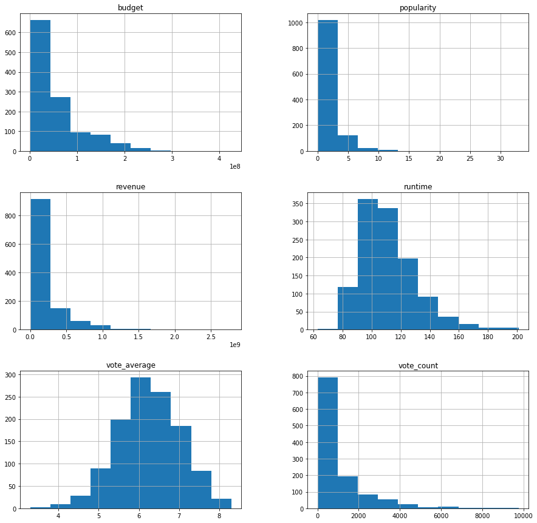

```python
df_clean.hist(figsize=(15,15));
```

### Research Question 6 (Is there a relation between budget and revenue?)

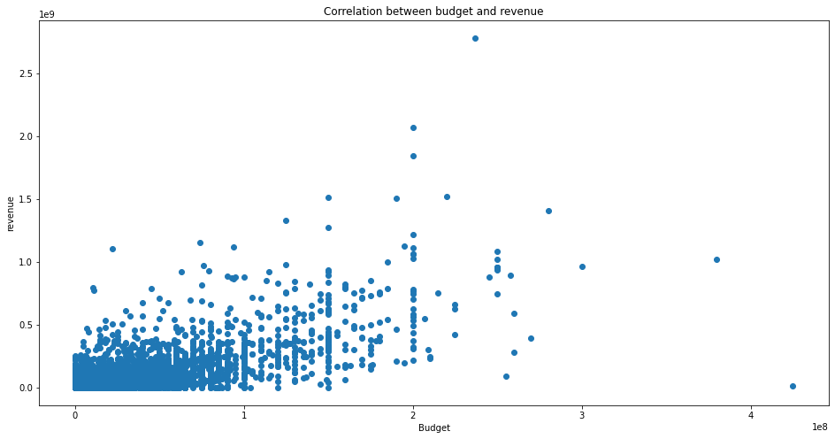

```python
plt.figure(figsize=(16,8))
plt.scatter(df.budget, df.revenue)
plt.xlabel('Budget')
plt.ylabel('revenue')
plt.title('Correlation between budget and revenue')
plt.show();
```

### Research Question 7 (Is there a relation between popularity and budget?)

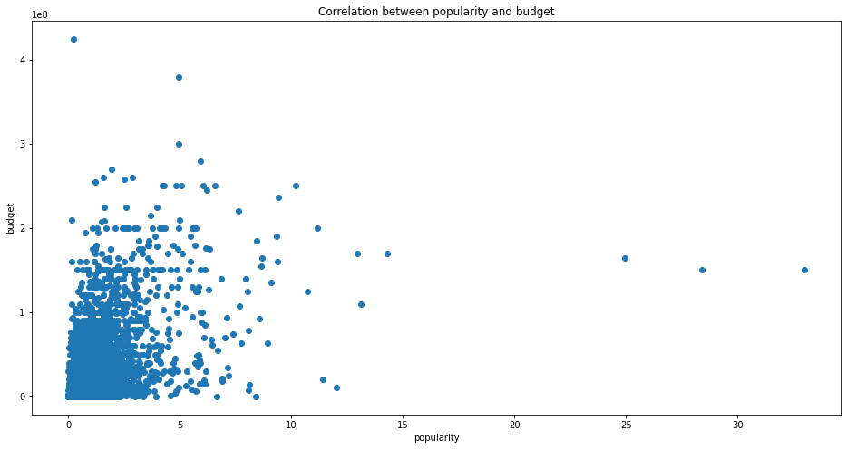

```python
plt.figure(figsize=(16,8))
plt.scatter(df.popularity, df.budget)
plt.xlabel('popularity')
plt.ylabel('budget')
plt.title('Correlation between popularity and budget')
plt.show();
```

### Research Question 8 (Is there a relation between popularity and revenue?)

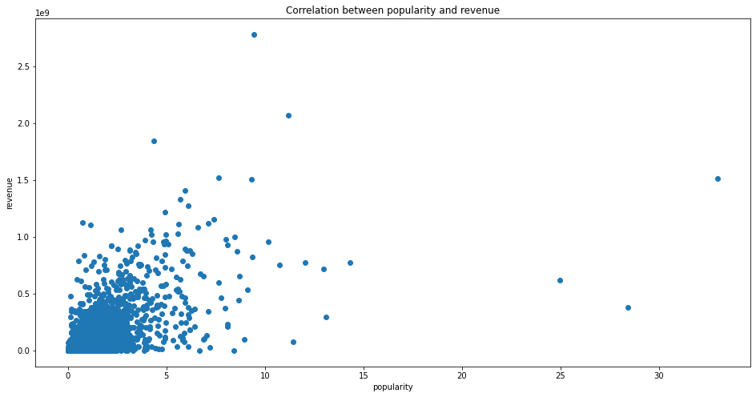

```python
plt.figure(figsize=(16,8))
plt.scatter(df.popularity, df.revenue)
plt.xlabel('popularity')
plt.ylabel('revenue')
plt.title('Correlation between popularity and revenue')
plt.show();
```

### Research Question 9 (what is the top 10 years related to movie released count?)

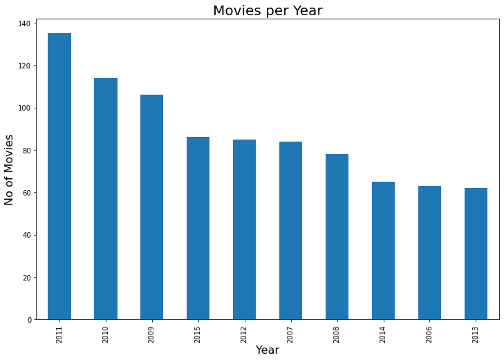

```python
df_clean.groupby(df_clean['release_date'].dt.year)['original_title'].count().sort_values(ascending=False).head(10).plot(kind = 'bar', figsize=(12,8))
plt.title('Movies per Year', fontsize=20)
plt.ylabel('No of Movies', fontsize=16)
plt.xlabel('Year', fontsize=16)
plt.show();
```

### Research Question 10 (What is the top 10 years related to popularity?)

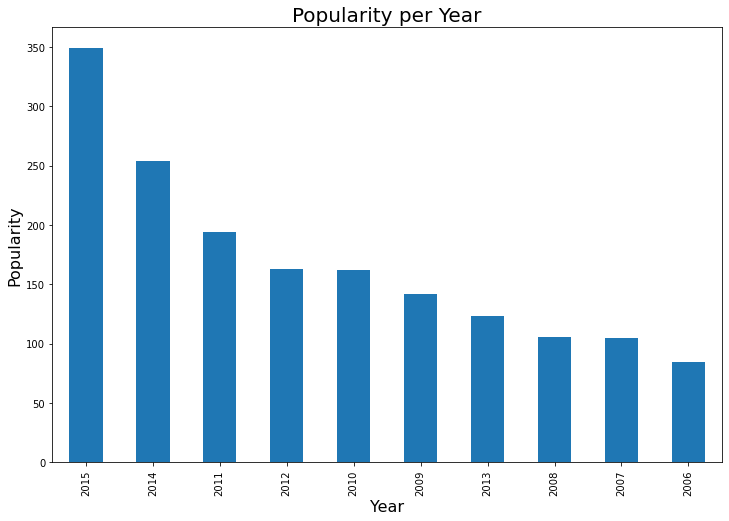

```python
df_clean.groupby(df_clean['release_date'].dt.year)['popularity'].sum().sort_values(ascending=False).head(10).plot(kind = 'bar', figsize=(12,8))
plt.title('Popularity per Year', fontsize=20)
plt.ylabel('Popularity', fontsize=16)
plt.xlabel('Year', fontsize=16)
plt.show();
```

### Research Question 11 (What is the top 10 years related to budget?)

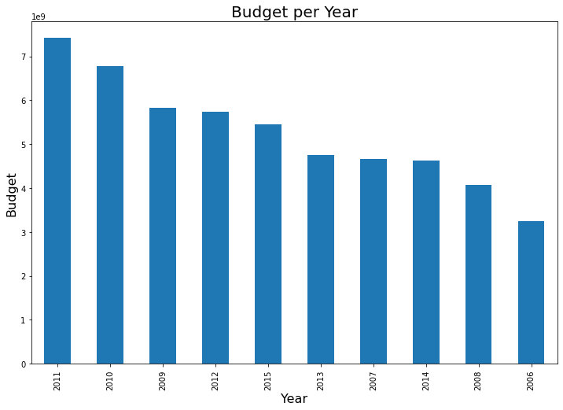

```python
df_clean.groupby(df_clean['release_date'].dt.year)['budget'].sum().sort_values(ascending=False).head(10).plot(kind = 'bar', figsize=(12,8))
plt.title('Budget per Year', fontsize=20)
plt.ylabel('Budget', fontsize=16)
plt.xlabel('Year', fontsize=16)
plt.show();
```

### Research Question 12 (What is the top 10 years related to revenue?)

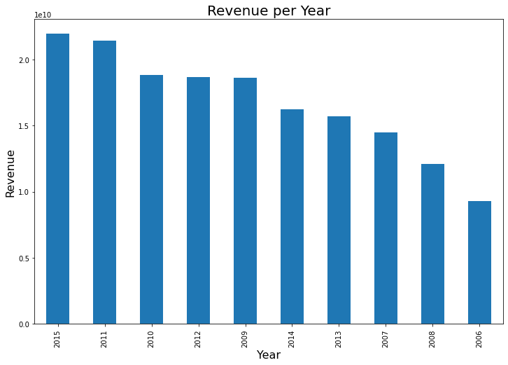

```python
df_clean.groupby(df_clean['release_date'].dt.year)['revenue'].sum().sort_values(ascending=False).head(10).plot(kind = 'bar', figsize=(12,8))
plt.title('Revenue per Year', fontsize=20)
plt.ylabel('Revenue', fontsize=16)
plt.xlabel('Year', fontsize=16)
plt.show();
```

### Research Question 13 (What is the most frequent genres?)

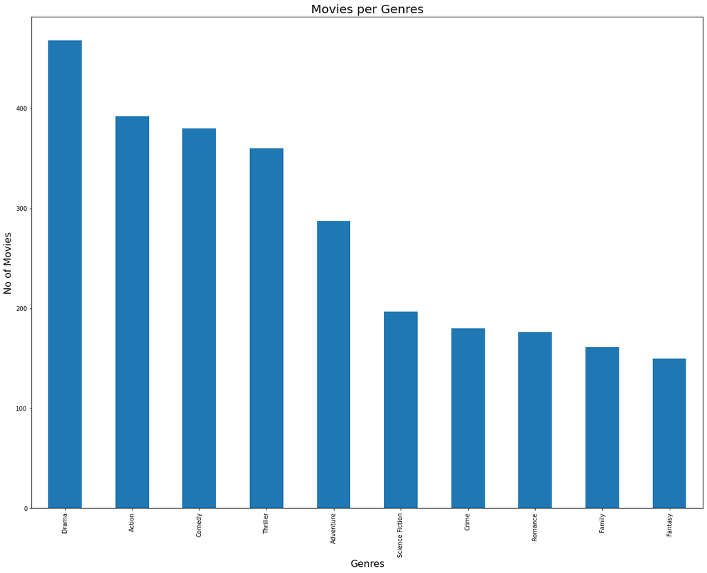

```python
df_clean_expanded_genres = df_clean.explode('genres')

df_clean_expanded_genres.genres.value_counts().sort_values(ascending=False).head(10).plot(kind = 'bar', figsize=(20,15))
plt.title('Movies per Genres', fontsize=20)
plt.ylabel('No of Movies', fontsize=16)
plt.xlabel('Genres', fontsize=16)
plt.show();
```

### Research Question 14 (What is the most popular genres?)

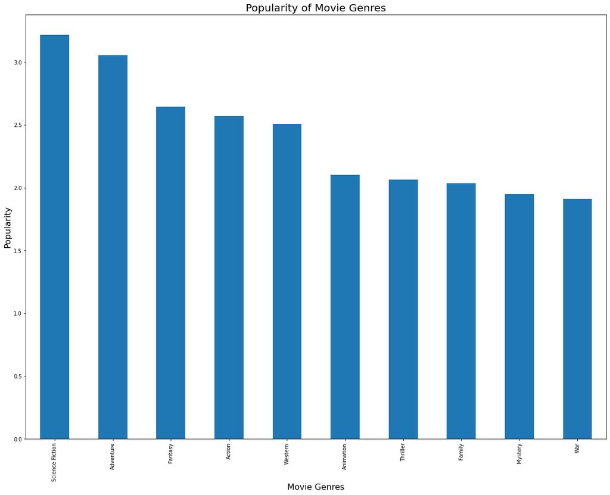

```python
df_clean_expanded_genres.groupby('genres').popularity.mean().sort_values(ascending=False).head(10).plot(kind = 'bar', figsize=(20,15))
plt.title('Popularity of Movie Genres', fontsize=20)
plt.ylabel('Popularity', fontsize=16)
plt.xlabel('Movie Genres', fontsize=16)
plt.show();
```

### Research Question 15 (What is the most costable genres?)

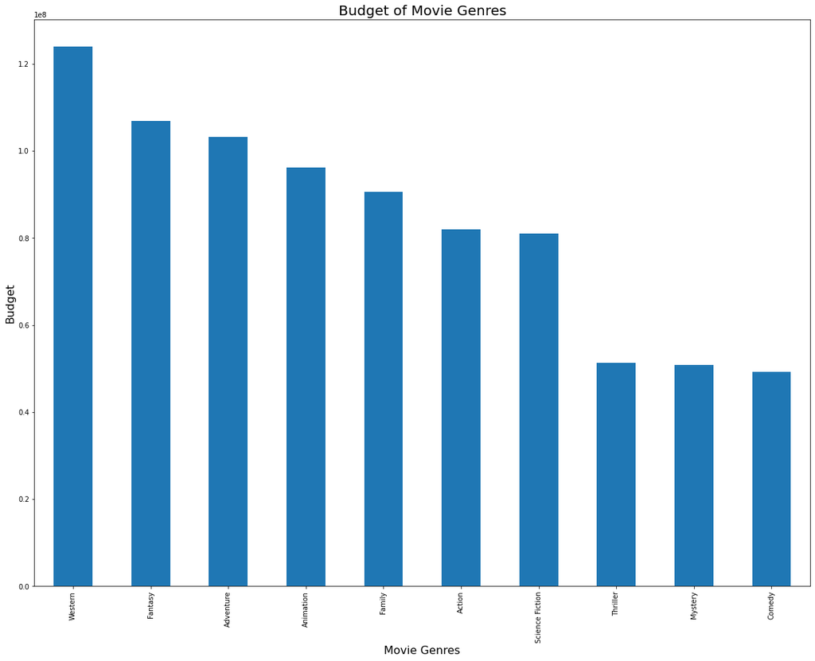

```python
df_clean_expanded_genres.groupby('genres').budget.mean().sort_values(ascending=False).head(10).plot(kind = 'bar', figsize=(20,15))
plt.title('Budget of Movie Genres', fontsize=20)
plt.ylabel('Budget', fontsize=16)
plt.xlabel('Movie Genres', fontsize=16)
plt.show();
```

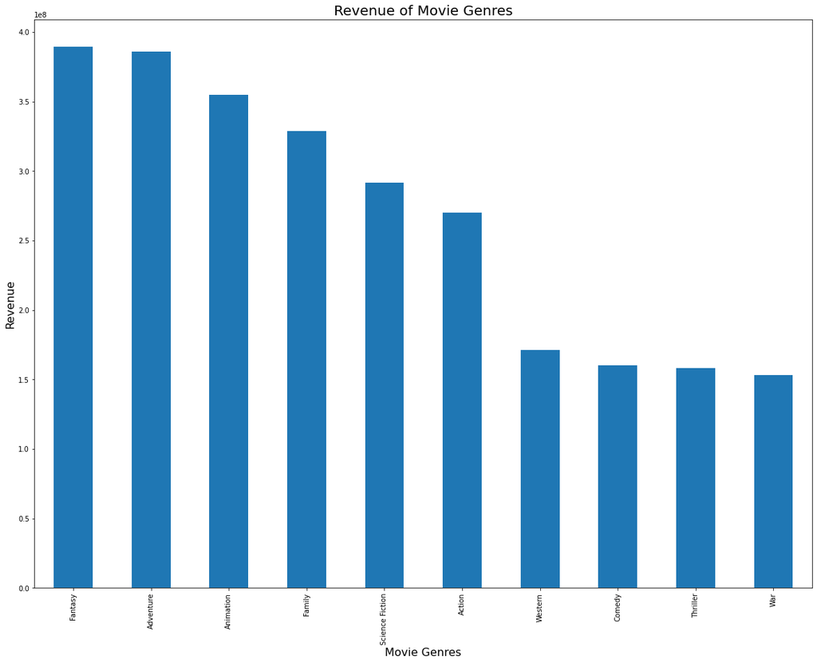

```python
df_clean_expanded_genres.groupby('genres').revenue.mean().sort_values(ascending=False).head(10).plot(kind = 'bar', figsize=(20,15))
plt.title('Revenue of Movie Genres', fontsize=20)
plt.ylabel('Revenue', fontsize=16)
plt.xlabel('Movie Genres', fontsize=16)
plt.show();
```

### Research Question 17 (Who is the Cast Member that participated in highest no of movies? )

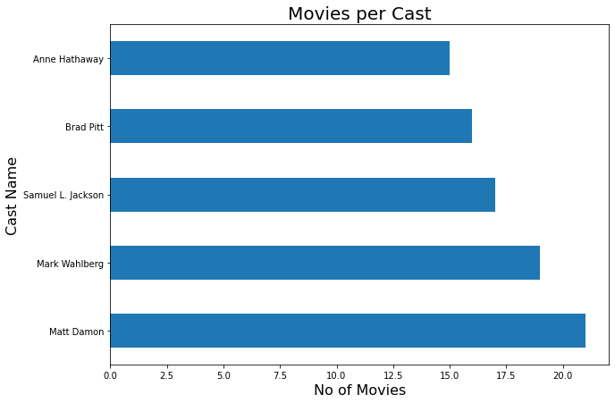

```python
df_clean_expanded_cast = df_clean.explode('cast')

df_clean_expanded_cast.cast.value_counts().sort_values(ascending=False).head().plot(kind = 'barh', figsize=(10,7))
plt.title('Movies per Cast', fontsize=20)
plt.ylabel('Cast Name', fontsize=16)
plt.xlabel('No of Movies', fontsize=16)
plt.show();
```

### Research Question 18 (What is The top 5 Production companies with highest money spent in budget? )

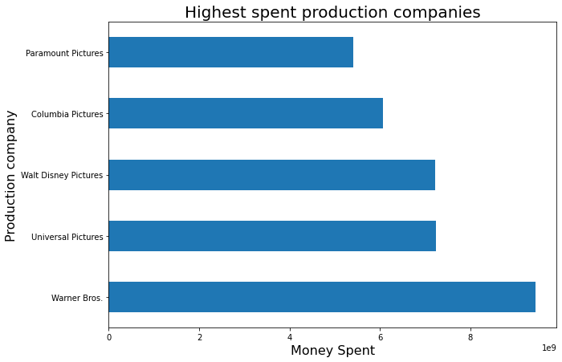

```python
df_clean_expanded_production_companies = df_clean.explode('production_companies')

df_clean_expanded_production_companies.groupby('production_companies')['budget'].sum().sort_values(ascending=False).head().plot(kind = 'barh', figsize=(10,7))
plt.title('Highest spent production companies', fontsize=20)
plt.ylabel('Production company', fontsize=16)
plt.xlabel('Money Spent', fontsize=16)
plt.show();
```

## Conclusions

> From first question (what is the 5 most popular movies?), we found that the Jurassic World movie is the first popular movie then Mad Max: Fury Road movie then Interstellar movie then Guardians of the Galaxy movie and the fifth one is Insurgent.

> From second question (What is the 5 most costable movies ?), we found that The Warrior's Way movie is the most costable movie then Pirates of the Caribbean: On Stranger Tides movie then Pirates of the Caribbean: At World's End movie then Avengers: Age of Ultron movie and the fifth one is Tangled movie.

> From third question (What is the 5 most revenue movies ?), we found that Avatar is the first then Star Wars: The Force Awakens, after that Titanic, then The Avengers then jurassic World.

> From the 4th question (What is the heighest 5 vote count movies ?), we found that Inception is the top one followed by The Avengers then Avatar after that The Dark Knight and the fifth one is Django Unchained.

> From the 9th question (what is the top 10 years related to movie released count?), we found that 2011 is the first followed by 2010, 2009, 2015, 2012, 2007, 2008, 2014, 2006 and the 10th is 2013.

> From the 10th question (What is the top 10 years related to popularity?), we found that 2015 is the first then 2014, 2011, 2012, 2010, 2009, 2013, 2008, 2007, 2006.

> From the 11th question (What is the top 10 years related to budget?), we found that 2011 is the first then 2010, 2009, 2012, 2015, 2013, 2007, 2014, 2008 and the 10th is 2006.

> From the 12th question (What is the top 10 years related to revenue?), we found that 2015 is the top year, then 2011, 2010, 2012, 2009, 2014, 2013, 2007, 2008 and 2006.

> From the 13th question (What is the most frequent genres?), we found that Drama is the first, then Action, then Comedy, then Thriller, then Adventure, then Science Fiction, then Crime, then Romance, then Family , then Fantasy.

> From the 14th question (What is the most popular genres?), we found that Science Fiction is the first, then Adventure, then Fantasy, then Action, then Western, then Animation, then Thriller, then Family, then Mystery, then War.

> From the 15th question (What is the most costable genres?), we found that Western is the first, then Fantasy, then Adventure, then Animation, then Family, then Action, then Science Fiction, then Thriller , then Mystery and the 10th is Comedy.

> From the 17th question (Who is the Cast Member that participated in highest no of movies?), we found that Matt Damon participated in 21 movie, then Mark Wahlberg participated in 19 movie, then Samuel L. Jackson participated in 17 movie, then Brad Pitt participated in 16 movie, then Anne Hathaway participated in 15.

> From the 18th question (What is The top 5 Production companies with highest money spent in budget?), we found that Warner Bros. company spent 9435800003$, then Universal Pictures company spent 7235446652$, then Walt Disney Pictures company spent 7218000000$, then Columbia Pictures company spent 6061100000$, then Paramount Pictures company spent 5407000000$.

> Future Questions:
> - Is there a relation between release month and budget, revenue and popularity?
> - Is there a cast member participated in most of the popular movie or movies that got high vote count?
> - Is the runtime of the movie affect its popularity, vote count, vot average or budget?

## Limitation

> The drop for the rows that has zero values in budget, revenue and runtime, can be avoided by further investigation and more data

> The drop for the rows that have release date in the future can be avoided by further investigation.